# ChEn 541: Exam 1: Winter 2015

# Due Friday October 20, BEFORE 9:00 AM

# Problem 2

## Open book, open notes. Closed homework, homework solutions, and closed code examples. You may use the internet for Matlab and Python help only.

### Part a

A chemical reaction occurs in a continuous stirred tank reactor (CSTR). There is an inlet, and an outlet. The contents are perfectly mixed and the outlet composition is the same as the reactor composition.

The reactions are

A + B --> C (reaction 1)

B + C --> D (reaction 2)

The reaction rates for the species are given by $$\begin{align} r_A &= -k_1[A][B] \\ r_B &= -k_1[A][B] - k_2[B][C] \\ r_C &= k_1[A][B] - k_2[B][C] \\ r_D &= k_2[B][C] \end{align}$$

The mass balance for each species in the CSTR is $$ \frac{d[Y]}{dt} = \frac{[Y]_{in}-[Y]}{\tau} + r,$$ where $[Y]$ is one of $[A]$, $[B]$, $[C]$, or $[D]$. Also, $\tau$ is the residence time in the reactor (volume divided by volumetric flow rate).

Solve for the concentrations $[Y]$ as functions of time to an end time of $5\tau$ as described below. Also solve for the selectivity $S=C/(C+D)$, where C is a desired product and D is undesired. (This is initially undefined, so set the initial selectivity to 1.0.

The initial concentration in the tank is $[B]_0 = 1.0$ and all other species are zero.

The inlet concentrations are $[A]_{in} = 1.0$, and $[B]_{in} = 1.0$.

Take $\tau=10.0$, $k_1=1.0$, $k_2=5.0$. Use an initial stepsize of $dt=0.01$.

You should plot the concentrations and selectivity on the same plot. (Include a legend.) Use a linestyle that includes symbols so the step size is clear. On a separate plot, show the stepsize versus time. Use a log scale for the stepsize.

You should solve the problem using the Implicit Euler method. This is a nonlinear, multidimensional problem. You will need a nonlinear solver. Use Newton's method with an analytic Jacobian. You can use a built-in (Matlab or Python) linear solver. Set the step size using the step doubling technique. Use a relative tolerance of 0.005 for all error testing, and use the 2-norm. You may want to solve this in steps, making sure things work before adding complexity.

In order to solve this problem, we need a general formula for implicit Euler.

1. $\vec{y}_{n+1} = \vec{y}_n + h\left[\vec{f}(\vec{y}_{n+1})\right]$
2. Use Newton's method identity.  
   $\vec{y}_{n+1} \approx \vec{y}_n + h\left[\vec{f}(\vec{y}_n) + \frac{d\vec{f}}{d\vec{y}}\Big\vert_{\vec{y}_n}\cdot (\vec{y}_{n+1} - \vec{y}_n)\right]$
3. $\vec{y}_{n+1} - \vec{y}_n\approx h\left[\vec{f}(\vec{y}_n) + \frac{d\vec{f}}{d\vec{y}}\Big\vert_{\vec{y}_n}\cdot (\vec{y}_{n+1} - \vec{y}_n)\right]$
4. $\vec{y}_{n+1} - \vec{y}_n\approx h\vec{f}(\vec{y}_n) + h\frac{d\vec{f}}{d\vec{y}}\Big\vert_{\vec{y}_n}\cdot (\vec{y}_{n+1} - \vec{y}_n)$
5. $\left(\vec{y}_{n+1} - \vec{y}_n\right) -h\frac{d\vec{f}}{d\vec{y}}\Big\vert_{\vec{y}_n}\cdot (\vec{y}_{n+1} - \vec{y}_n) \approx h\vec{f}(\vec{y}_n)$
6. $\left(\mathbf{I} -h\frac{d\vec{f}}{d\vec{y}}\Big\vert_{\vec{y}_n}\right)\left(\vec{y}_{n+1} - \vec{y}_n\right) \approx h\vec{f}(\vec{y}_n)$
7. $\:\:\:\:\:\:\:\:\:\:\:\:\:\:\mathbf{A}\:\:\:\:\:\:\:\:\:\:\:\:\:\:\:\:\:\:\:\:\:\vec{x} \:\:\:\:\:\:\:\: \:\: =\:\:\:\:\:\:\:\:\:\vec{b}$
8. Solve $\mathbf{A}\vec{x}=\vec{b}$ with built in solver.
9. $\vec{y}_{n+1} = \vec{x}+\vec{y}_{n}$. $QED$

```python
from scipy.integrate import odeint
%matplotlib inline
myBool = False
```

```python
tau = 10.
k1 = 1.0
k2 = 5.0
dt = .01
def f(y,t=0):
    """System of ODEs"""
    dy = np.zeros(4)
    #This is where we calculate the function
    dy[0] = (1-y[0])/tau - k1*y[0]*y[1]
    dy[1] = (1-y[1])/tau - k1*y[0]*y[1] - k2*y[1]*y[2]
    dy[2] = -y[2]/tau    + k1*y[0]*y[1] - k2*y[1]*y[2]
    dy[3] = -y[3]/tau                   + k2*y[1]*y[2]
    return dy

def Jac(y):
    """Analytical Jacobian to solve problem statement"""
    J = np.zeros([4,4])
    J[0,0] = -1/tau - k1*y[1]
    J[0,1] =        - k1*y[1]
    J[0,2] =          k1*y[1]
    J[0,3] = 0
    J[1,0] =        - k1*y[0]
    J[1,1] = -1/tau - k1*y[0] - k2*y[2]
    J[1,2] =          k1*y[0] - k2*y[2]
    J[1,3] =                    k2*y[2]
    J[2,0] = 0
    J[2,1] =                  - k2*y[1]
    J[2,2] = -1/tau           - k2*y[1]
    J[2,3] =                    k2*y[1]
    J[3,0] = 0
    J[3,1] = 0
    J[3,2] = 0
    J[3,3] = -1/tau
    return J
def ODEstep(f,J,y0,dt0,tend=50,rtol=0.005,maxit=100000):
    """ODEstep requires a system of derivatives, and a Jacobian function
    which it then uses to integrate the ODE using an adaptive step size
    and first order method (implicit Euler, well, semi-implicit Euler)"""
    y = np.zeros([1,5])
    t = np.zeros(1)
    m,n = np.shape(y)
    #I = np.ones([4,4])
    I = np.identity(4)
    ###This work is scratch work to show what I'm doing###
    #ynp1 = yn + fnp1*deltat
    #fnp1 = J*ynp1 + b
    #ynp1 = yn + (J*ynp1) * deltat
    #ynp1 - J*ynp1 = yn * deltat
    #(1-J)*ynp1 = yn * deltat
    y[0,:4]=y0
    y[0,-1]=1
    it=1
    dt = dt0
    dtList = [dt0]
    dtList2 = []
    #Iterate through time
    while t[-1] < tend:
        try:
            J2 = (I-dt*J(y[-1,:4]))
            y1=y[-1,:4] + np.linalg.solve(J2,dt*f(y[-1,:4],t[-1]))
            J2_2 = (I-dt*2*J(y[-1,:4]))
            y2 = y[-1,:4] + np.linalg.solve(J2_2,dt*2*f(y[-1,:4],t[-1]))
            err = np.linalg.norm(y2 - y1)
            if err < (np.max(y1)*rtol):
                t=np.vstack((t,t[-1]+dt))
                y=np.vstack((y,np.hstack((y1,y1[2]/(y1[2]+y1[3]) ))))
                dt = dt*(np.max(np.abs(y1*rtol))/err)
                dtList.append(dt)
               # dtList2.append([err,dt,t[-1]])
            else:
                dt = dt*(np.max(np.abs(y1*rtol))/err)
                #dtList2.append([err,dt,t[-1]])
            if it > maxit:
                return y,t
            it+=1
        except (np.linalg.linalg.LinAlgError, IndexError) as Err:
            print(J2,i)
            print(Err)
            break
    return y,t,dtList#,dtList2
tend = 5*tau
#t = np.arange(0,tend,dt)
y0 = [0.,1.,0.,0.]
y,t,dts = ODEstep(f,Jac,y0,dt,tend)
```

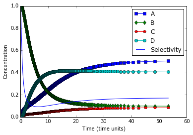

```python
plt.plot(t,   y[:,0],'b-s',label = 'A')
plt.plot(t,   y[:,1],'g-d',label = 'B')
plt.plot(t,   y[:,2],'r-p',label = 'C')
plt.plot(t,   y[:,3],'c-o',label = 'D')
plt.plot(t,   y[:,4],label = 'Selectivity')
plt.legend(loc='best')
plt.xlabel('Time (time units)')
muffle=plt.ylabel('Concentration')
```

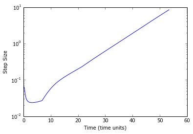

```python
plt.semilogy(t,dts)
plt.xlabel('Time (time units)')
muffle=plt.ylabel('Step Size')
```

### Part b

Write a function to solve the system $Ax=b$ using the Gauss Seidel method.

In Matlab fill in your function as:

```
function x = linear_gs(A, b)
   % write the solution here
end
```

In Python, fill in your function as:

```
def linear_gs(A,b) :
    # write the solution here
    return x
```

```python
import scipy.sparse
from scipy.sparse.linalg import spsolve
from scipy.sparse import lil_matrix, spdiags
```

```python
def linear_gs(A,b,itMax=1000,atol=1e-6):
    """This method requires a diagonally dominant matrix,
    or it may diverge..."""
    n,m = np.shape(A)
    nb, = np.shape(b)
    if nb != n:
        raise np.linalg.linalg.LinAlgError("A and b have different dimensions.")
    R = b.copy()
    x = b.copy()
    indx = np.arange(0,nb)
    R[0]=100
    it = 0
    myBool = True
    while myBool:
        myBool = False
        for i in range(n):
            if A[indx[i],i]==0:
                myBool = True
                if i == n-1:
                    i = -1
                    print("weird...")
                tmp = indx[i+1]
                indx[i]=indx[i+1]
                indx[i+1]=tmp
        it +=1
        if it > itMax:
            print("Error, rank seems to be deficient")
            return b
    Err = atol*100
    while Err> atol:
        for i in range(n):

            R[i] = b[indx[i]].copy()
            for j in range(i):
                R[i]-= A[indx[i],j]*x[j]
            for j in range(i+1,n):
                R[i]-= A[indx[i],j]*x[j]
            x[i] = 1/A[indx[i],i]*R[i]
        Err = np.linalg.norm(A.dot(x)-b)
        it+=1
        if it > itMax:
            print("Bad day. Didn't converge. Here's my best guess.")
            return x[indx]
    return x[indx]
```

```python
n = 30
D = np.array([np.ones(n), -1.*np.ones(n), 4.*np.ones(n), -1.*np.ones(n), np.ones(n)])
d = [-4,-2,0,2,6]
A = spdiags(D,d,n,n)
b = np.random.random(n)
A = A.tocsr()
x=linear_gs(A,b)
print(x)
```

```
[ 0.10318508  0.02412827  0.25020548  0.01071355  0.26521511  0.0637787
  0.23529226 -0.0110666   0.07435309  0.05489678  0.03540587  0.2848334
 -0.05205619  0.27649507  0.05317181  0.01731058  0.29727726 -0.08912096
  0.24552312  0.11171829  0.06955821  0.31652621  0.03211852  0.28580956
  0.15445159  0.04799932  0.11309191 -0.00824927  0.04557009  0.06567073]
```